# Introducing eulerr

Johan Larsson

2020-03-09

## Motivation

**eulerr** generates area-proportional euler diagrams that display set relationships (intersections, unions, and disjoints) with circles or ellipses. [Euler diagrams](https://en.wikipedia.org/wiki/Euler_diagram) are Venn diagrams without the requirement that all set interactions be present (whether they are empty or not). That is, depending on input, eulerr will sometimes produce Venn diagrams but sometimes not.

R features several packages that produce Euler diagrams; some of the more prominent ones (on CRAN) are

- eVenn,
- VennDiagram
- venn
- colorfulVennPlot, and
- venneuler.

The last of these (**venneuler**) was the primary inspiration for this package, along with the refinements that Fredrickson has presented on his [blog](http://www.benfrederickson.com/) and made available in his javascript venn.js. [eulerAPE](http://www.eulerdiagrams.org/eulerAPE/), which was the first program to uses ellipses instead of circles, has also been instrumental in the design of **eulerr**. The downside to **eulerAPE** is that it only handles three sets that all need to intersect.

**venneuler**, on the other hand, will take any number of sets (in theory), yet has been known to produce [imperfect solutions](http://benfred.github.io/venn.js/tests/venneuler_comparison/) for set configurations that have perfect such. And unlike **eulerAPE**, it is restricted to circles (as is **venn.js**).

## Enter eulerr

**eulerr** is based on the improvements to venneuler that Ben Fredrickson introduced with **venn.js** but has been programmed from scratch, uses different optimizers, and returns statistics featured in **venneuler** and **eulerAPE** as well as allows a range of different inputs and conditioning on additional variables. Moreover, it can model set relationships with ellipses for any number of sets involved.

## Input

At the time of writing, it is possible to provide input to **eulerr** as either

- a named numeric vector with set combinations as disjoint set combinations or unions (depending on how the argument `type` is set in `euler()`),
- a matrix or data frame of logicals with columns representing sets and rows the set relationships for each observation,
- a list of sample spaces, or
- a table.

```r
library(eulerr)

# Input in the form of a named numeric vector
fit1 <- euler(c("A" = 25, "B" = 5, "C" = 5,
                "A&B" = 5, "A&C" = 5, "B&C" = 3,
                "A&B&C" = 3))

# Input as a matrix of logicals
set.seed(1)
mat <- cbind(
  A = sample(c(TRUE, TRUE, FALSE), 50, TRUE),
  B = sample(c(TRUE, FALSE), 50, TRUE),
  C = sample(c(TRUE, FALSE, FALSE, FALSE), 50, TRUE)
)
fit2 <- euler(mat)
```

We inspect our results by printing the eulerr object

```r
fit2
```

```
#>       original fitted residuals regionError
#> A           13     13         0       0.008
#> B            4      4         0       0.002
#> C            0      0         0       0.000
#> A&B         17     17         0       0.010
#> A&C          5      5         0       0.003
#> B&C          1      0         1       0.024
#> A&B&C        2      2         0       0.001
#>
#> diagError: 0.024
#> stress:    0.002
```

or directly access and plot the residuals.

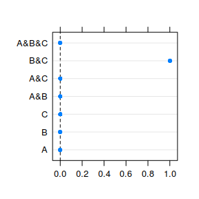

Residuals for the fit diagram.

```r
# Cleveland dot plot of the residuals
library(lattice)
dotplot(resid(fit2), xlab = "",
        panel = function(...) {
          panel.abline(v = 0, lty = 2)
          panel.dotplot(...)
        })
```

We can also use **eulerr**’s built in `error_plot()` function to diagnose the fit.

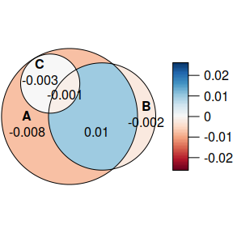

A plot from `error_plot()`.

```r
error_plot(fit2)
```

As an alternative, we could plot the circles in another program by retrieving their coordinates and radii.

```r
coef(fit2)
```

```
#>         h       k     a     b phi
#> A -0.5309 -0.2497 3.432 3.432 2.5
#> B  1.1125 -0.2497 2.706 2.706 2.5
#> C -1.5067  1.4108 1.493 1.493 2.5
```

### Goodness-of-fit

To tell if we can trust our solution, we use two goodness-of-fit measures: the stress statistic from **venneuler** (Wilkinson 2012),

$$\frac{\sum_{i=1}^{n} (y_i - \hat{y}_i)^2}{\sum_{i=1}^{n} y_i ^ 2}$$

where $\hat{y}_i$ is an ordinary least squares estimate from the regression of the fitted areas on the original areas that is being explored during optimization,

and the *diagError* statistic from **eulerAPE** (Micallef and Rodgers 2014):

$$\max_{i = 1, 2, \dots, n} \left| \frac{y_i}{\sum y_i} -
\frac{\hat{y}_i}{\sum \hat{y}_i} \right|$$

We can now be confident that eulerr provides a reasonable representation of our input using circles. Were it otherwise, we might try to use ellipses instead. (Wilkinson 2012) features a difficult combination that it manages to fit with a reasonably small error; with **eulerr**, however, we can get rid of that error entirely.

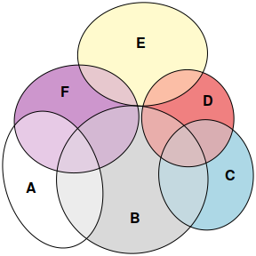

A difficult combination from Wilkinson 2012.

```r
wilkinson2012 <-  c(A = 4, B = 6, C = 3, D = 2, E = 7, F = 3,
                    "A&B" = 2, "A&F" = 2, "B&C" = 2, "B&D" = 1,
                    "B&F" = 2, "C&D" = 1, "D&E" = 1, "E&F" = 1,
                    "A&B&F" = 1, "B&C&D" = 1)
fit3 <- euler(wilkinson2012, shape = "ellipse")
plot(fit3)
```

If we still lack a good fit after having tried ellipses, we would do best to stop here and look for another way to visualize our data. (I suggest the excellent UpSetR package.)

### Visualization

No we get to the fun part: plotting our diagram. This is easy, as well as highly customizable, with **eulerr**. The default parameters can easily be adjusted to suit anybody’s needs.

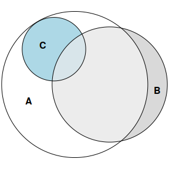

```r
plot(fit2)
```

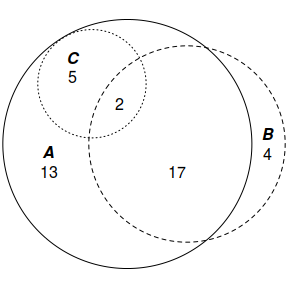

Customizing Euler plots is a breeze in eulerr.

```r
# Remove fills, vary borders, display quantities, and switch font.
plot(fit2,
     quantities = TRUE,
     fill = "transparent",
     lty = 1:3,
     labels = list(font = 4))
```

Plotting is provided through a custom plotting method built on top of the excellent facilities made available by the core R package **grid**. **eulerr**’s default color palette is chosen to be color deficiency-friendly.

## Acknowledgements

**eulerr** would not be possible without Ben Fredrickson’s work on **venn.js** or Leland Wilkinson’s **venneuler**.

## References

Micallef, Luana, and Peter Rodgers. 2014. “eulerAPE: Drawing Area-Proportional 3-Venn Diagrams Using Ellipses.” *PLOS ONE* 9 (7): e101717. https://doi.org/10.1371/journal.pone.0101717.

Wilkinson, L. 2012. “Exact and Approximate Area-Proportional Circular Venn and Euler Diagrams.” *IEEE Transactions on Visualization and Computer Graphics* 18 (2): 321–31. https://doi.org/10.1109/TVCG.2011.56.